# R pour les sciences marines — niveau intermédiaire

Partie 3 · Séances I9 à I13 — Distributions, tests, cartes, exercices, projet final

Aroo Falinirina

## Au programme

- **I9** : distributions, transformations, ce que signifie une p-value
- **I10** : comparer des moyennes et des pourcentages, corrélations : **choisir le bon test**
- **I11** : premières cartes avec ggplot2
- **I12** : séance d’exercices · **I13** : projet final (holothuries)

~20 min I9 · ~25 min I10 · ~10 min I11 · ~5 min I12–I13. Insister : le but est d’apprendre R, pas un cours complet de statistique.

## I9 — Distributions et p-values

## Regarder la forme d’abord

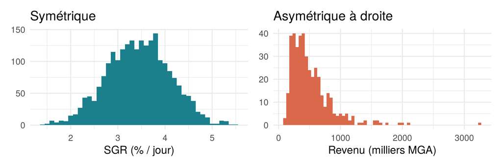

```r
p1 <- ggplot(seaweed, aes(sgr)) + geom_histogram(binwidth = 0.1, fill = "#1b7f8c", na.rm = TRUE) +
  labs(x = "SGR (% / jour)", y = NULL, title = "Symétrique")
p2 <- ggplot(hh, aes(monthly_income_mga / 1000)) + geom_histogram(binwidth = 50, fill = "#d9694a") +
  labs(x = "Revenu (milliers MGA)", y = NULL, title = "Asymétrique à droite")
p1 | p2
```

```r
c(moyenne = mean(inc), mediane = median(inc))
```

```
#> moyenne mediane
#>  516950  426000
```

## La loi normale et le QQ-plot

- 68 % des valeurs dans moyenne ± 1 ET, **95 % dans ± 1,96 ET**
- QQ-plot : des données normales **suivent la droite**

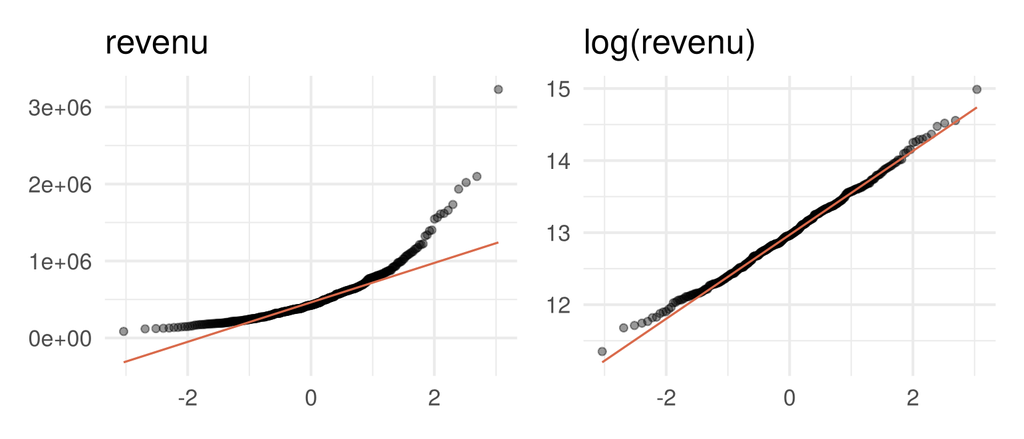

```r
qq <- function(x, t) ggplot(data.frame(x = x), aes(sample = x)) + stat_qq(alpha = .4) +
  stat_qq_line(colour = "#d9694a") + labs(title = t, x = NULL, y = NULL)
qq(inc, "revenu") | qq(log(inc), "log(revenu)")
```

## Shapiro–Wilk : un complément, pas un juge

```r
shapiro.test(inc)$p.value; shapiro.test(log(inc))$p.value
```

```
#> [1] 1.810141e-22
#> [1] 0.4517445
```

- petit n : ne rejette presque jamais · grand n : rejette pour des écarts minimes
- avec de **grands groupes**, les moyennes sont presque normales (théorème central limite)

Ordre : histogramme + QQ-plot → décision → (test de Shapiro en complément).

## Transformer

| Données | Transformation |
| --- | --- |
| positives, asymétriques (revenu, biomasse) | `log(x)` |
| idem avec des zéros | `log1p(x)` |
| comptages | `sqrt(x)` |

```r
geo_mean <- function(x) exp(mean(log(x)))     # re-transformer : moyenne géométrique
c(arithmetique = mean(inc), geometrique = geo_mean(inc), mediane = median(inc))
```

```
#> arithmetique  geometrique      mediane
#>     516950.0     437185.9     426000.0
```

## Une p-value, construite à la main

```r
li <- log(inc); g <- hh$does_seaweed
obs <- mean(li[g]) - mean(li[!g]); exp(obs)      # +7,5 % pour les ménages algoculteurs
```

```
#> [1] 1.075095
```

```r
set.seed(42)
perm <- replicate(5000, { s <- sample(g); mean(li[s]) - mean(li[!s]) })   # H0 : étiquettes au hasard
mean(abs(perm) >= abs(obs))                      # = la p-value
```

```
#> [1] 0.2166
```

**p-value** = probabilité d’un résultat au moins aussi extrême **si H0 était vraie**.

## Ce qu’une p-value n’est pas

- pas la probabilité que H0 soit vraie
- **non significatif ≠ pas d’effet** : « pas de preuve d’une différence »
- **significatif ≠ important** : regarder la taille d’effet et son IC
- 0,05 est une convention : 0,049 ≈ 0,051

## I10 — Choisir le bon test

## Le schéma de décision

[figure not shown]

## Paramétrique ou non paramétrique ?

|  | Paramétrique | Non paramétrique |
| --- | --- | --- |
| utilise | les valeurs (moyenne, ET) | les **rangs** |
| suppose | ~ normal (ou grands groupes) | formes semblables |
| exemples | `t.test()`, Pearson | `wilcox.test()`, Spearman |
| + | plus puissant, effet en unités | robuste aux extrêmes |

Choisir **avant** de voir p. Ne pas faire les deux tests pour garder celui qui « marche ».

## Deux moyennes indépendantes

```r
tt <- t.test(sgr ~ season, data = seaweed)       # Welch par défaut
round(c(tt$estimate, diff = unname(diff(rev(tt$estimate))), tt$conf.int, p = tt$p.value), 3)
```

```
#> mean in group dry mean in group wet              diff
#>             3.563             3.302             0.261             0.207
#>                                   p
#>             0.314             0.000
```

```r
wilcox.test(monthly_income_mga ~ head_sex, data = hh)$p.value   # revenu asymétrique
```

```
#> [1] 0.4250528
```

« Les algues ont poussé plus vite en saison sèche (3,56 vs 3,30 % j⁻¹ ; différence 0,26, IC 95 % 0,21–0,31 ; Welch t = 9,56, p < 0,001). »

## Données appariées

```r
wq$year <- as.integer(format(wq$date, "%Y"))
sy <- wq %>% filter(year %in% 2024:2025) %>% group_by(station, year) %>%
  summarise(t = mean(temp_C, na.rm = TRUE), .groups = "drop") %>%
  pivot_wider(names_from = year, values_from = t, names_prefix = "y")
tp <- t.test(sy$y2025, sy$y2024, paired = TRUE); round(c(tp$estimate, tp$p.value), 3)
```

```
#> mean difference
#>          -0.100           0.021
```

−0,1 °C, p = 0,02 : **significatif mais minuscule** face aux variations saisonnières.

## Comparer des pourcentages

```r
tab <- table(farmers$sex, farmers$technique)
round(prop.table(tab, 1) * 100, 1)
```

```
#>
#>     long-line off-bottom
#>   F      52.7       47.3
#>   M      34.1       65.9
```

```r
chisq.test(tab)$expected                 # tous >= 5 ? sinon fisher.test()
```

```
#>
#>     long-line off-bottom
#>   F  24.63542   30.36458
#>   M  18.36458   22.63542
```

```r
round(c(chi2 = chisq.test(tab)$p.value, fisher = fisher.test(tab)$p.value), 3)
```

```
#>   chi2 fisher
#>  0.109  0.097
```

53 % vs 34 % mais n = 96 : **pas de preuve convaincante** — ce n’est pas une preuve d’égalité.

## Corrélation : Pearson ou Spearman

```r
cor(wq$temp_C, wq$DO_mgL, use = "complete.obs")                                   # Pearson
```

```
#> [1] -0.5516088
```

```r
cor(seaweed$temp_mean, seaweed$sgr, use = "complete.obs", method = "spearman")    # Spearman
```

```
#> [1] -0.1875033
```

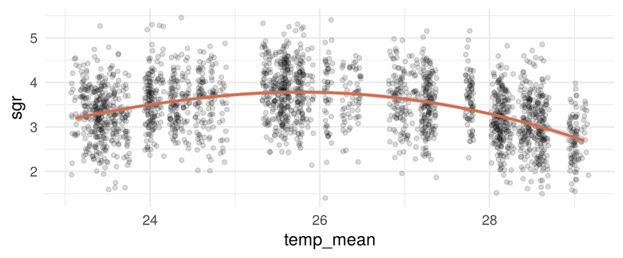

```r
ggplot(seaweed, aes(temp_mean, sgr)) + geom_jitter(width = .05, alpha = .15, na.rm = TRUE) +
  geom_smooth(method = "loess", formula = y ~ x, colour = "#d9694a", na.rm = TRUE)
```

## Quand aucun coefficient ne convient

- la croissance **monte** jusqu’à ~25–26 °C puis **descend** : relation forte mais **non monotone**
- Pearson et Spearman ≈ −0,19 : ils mélangent les deux pentes
- **tracer avant de calculer** ; décrire une courbe par le graphique
- corrélation ≠ causalité · une question = un test (20 tests → ~1 faux positif)

## I11 — Cartes avec ggplot2

## Une carte = un nuage de points + un polygone

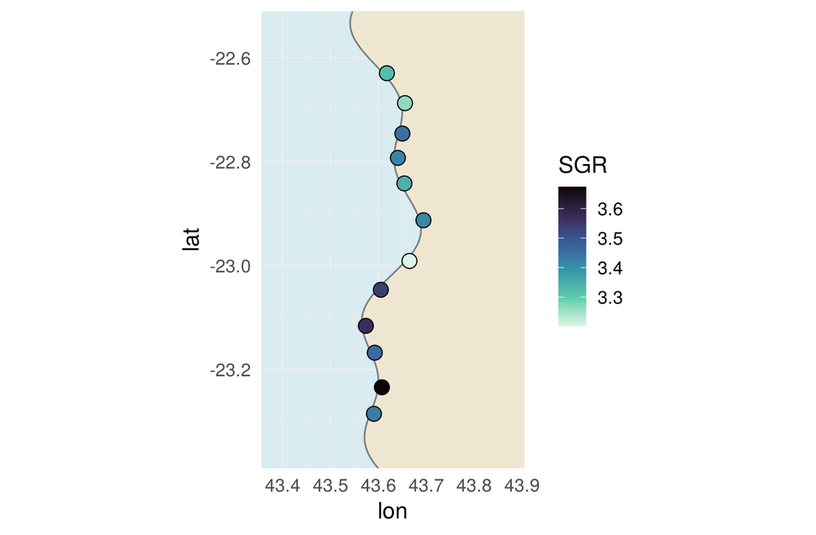

```r
coast <- read.csv("data/coastline.csv"); villages <- read.csv("data/villages.csv")
growth <- seaweed %>% group_by(village) %>% summarise(m = mean(sgr, na.rm = TRUE))
gm <- left_join(villages, growth, by = "village")
ggplot() + geom_polygon(data = coast, aes(lon, lat), fill = "#efe6d2", colour = "grey50") +
  geom_point(data = gm, aes(lon, lat, fill = m), shape = 21, size = 4) +
  scale_fill_viridis_c(option = "mako", direction = -1, name = "SGR") +
  coord_quickmap(xlim = c(43.38, 43.88), ylim = c(-23.35, -22.55)) +
  theme(panel.background = element_rect(fill = "#d8ecf2", colour = NA))
```

## Les points clés des cartes

- x = **longitude**, y = **latitude** (sud = négatif), WGS84
- `coord_quickmap()` : bon rapport d’aspect ; `geom_polygon()` : lignes dans l’**ordre**
- résumer → **joindre** aux coordonnées → `size` (quantité) / `fill` (intensité)
- flèche du nord et échelle avec `annotate()` (0,09° de latitude ≈ 10 km)
- aperçu de **sf** (`st_as_sf()`, `geom_sf()`) → niveau avancé

## I12–I13 — Exercices et projet final

## Séance d’exercices (I12)

| Exercice | Séances | Fichier |
| --- | --- | --- |
| 1. import, codes manquants, dates | I0–I1 | `water_quality_long.csv` |
| 2. restructurer, joindre | I2–I3 | `water_quality_wide.csv`, enquête |
| 3. enquête et texte | I4 | `survey_households.csv` |
| 4. boucles, fonctions | I5–I6 | checkpoint qualité de l’eau |
| 5. graphiques | I7–I8 | checkpoint qualité de l’eau |
| 6. choisir un test | I9–I10 | qualité de l’eau + enquête |

## Projet final : holothuries en enclos (I13)

3 fermes × 8 enclos de *Holothuria scabra* ; 20 animaux pesés tous les 30 jours pendant 10 mois (4 800 pesées) ; survivants comptés à la récolte.

1. importer 3 tables, dates · 2. poids moyen par enclos et visite · 3. **SGR par enclos avec votre fonction**
2. table d’analyse : survie, biomasse, rendement · 5. figures (patchwork)
3. comparer Farm B / Farm C · 7. densité vs croissance · 8. carte · 9. interprétation

## Niveau suivant

- quiz : **2 tentatives**, la meilleure compte
- chaque séance s’ouvre quand la précédente a au moins **75 %** des points
- **75 %** du total des points du niveau (exercices inclus) → niveau **avancé** débloqué
- en difficulté ? un message vous propose une séance ensemble

**Niveau avancé** : projets reproductibles (renv, Git, GitHub), rapports R Markdown et Quarto automatiques, cartes avec sf, terra et tmap.